```python
import pandas as pd
import matplotlib.pyplot as plt
%matplotlib inline
```

# Including the dataset and exploring the dataset

```python
data = pd.read_csv('Cellphone.csv', index_col=0)
```

```python
data = pd.read_csv('Cellphone.csv')
```

```python
data.columns = ['Product_id','Price','Sale','weight','resoloution','ppi','cpucore','cpufreq','internalmem','ram','RearCam','Front_Cam','battery','thickness']
```

```python
data.head()
```

|  | Product_id | Price | Sale | weight | resoloution | ppi | cpucore | cpufreq | internalmem | ram | RearCam | Front_Cam | battery | thickness |
| --- | --- | --- | --- | --- | --- | --- | --- | --- | --- | --- | --- | --- | --- | --- |
| 0 | 203 | 2357 | 10 | 135.0 | 5.2 | 424 | 8 | 1.35 | 16.0 | 3.000 | 13.00 | 8.0 | 2610 | 7.4 |
| 1 | 880 | 1749 | 10 | 125.0 | 4.0 | 233 | 2 | 1.30 | 4.0 | 1.000 | 3.15 | 0.0 | 1700 | 9.9 |
| 2 | 40 | 1916 | 10 | 110.0 | 4.7 | 312 | 4 | 1.20 | 8.0 | 1.500 | 13.00 | 5.0 | 2000 | 7.6 |
| 3 | 99 | 1315 | 11 | 118.5 | 4.0 | 233 | 2 | 1.30 | 4.0 | 0.512 | 3.15 | 0.0 | 1400 | 11.0 |
| 4 | 880 | 1749 | 11 | 125.0 | 4.0 | 233 | 2 | 1.30 | 4.0 | 1.000 | 3.15 | 0.0 | 1700 | 9.9 |

```python
data.describe()
```

|  | Product_id | Price | Sale | weight | resoloution | ppi | cpucore | cpufreq | internalmem | ram | RearCam | Front_Cam | battery | thickness |
| --- | --- | --- | --- | --- | --- | --- | --- | --- | --- | --- | --- | --- | --- | --- |
| count | 161.000000 | 161.000000 | 161.000000 | 161.000000 | 161.000000 | 161.000000 | 161.000000 | 161.000000 | 161.000000 | 161.000000 | 161.000000 | 161.000000 | 161.000000 | 161.000000 |
| mean | 675.559006 | 2215.596273 | 621.465839 | 170.426087 | 5.209938 | 335.055901 | 4.857143 | 1.502832 | 24.501714 | 2.204994 | 10.378261 | 4.503106 | 2842.111801 | 8.921739 |
| std | 410.851583 | 768.187171 | 1546.618517 | 92.888612 | 1.509953 | 134.826659 | 2.444016 | 0.599783 | 28.804773 | 1.609831 | 6.181585 | 4.342053 | 1366.990838 | 2.192564 |
| min | 10.000000 | 614.000000 | 10.000000 | 66.000000 | 1.400000 | 121.000000 | 0.000000 | 0.000000 | 0.000000 | 0.000000 | 0.000000 | 0.000000 | 800.000000 | 5.100000 |
| 25% | 237.000000 | 1734.000000 | 37.000000 | 134.100000 | 4.800000 | 233.000000 | 4.000000 | 1.200000 | 8.000000 | 1.000000 | 5.000000 | 0.000000 | 2040.000000 | 7.600000 |
| 50% | 774.000000 | 2258.000000 | 106.000000 | 153.000000 | 5.150000 | 294.000000 | 4.000000 | 1.400000 | 16.000000 | 2.000000 | 12.000000 | 5.000000 | 2800.000000 | 8.400000 |
| 75% | 1026.000000 | 2744.000000 | 382.000000 | 170.000000 | 5.500000 | 428.000000 | 8.000000 | 1.875000 | 32.000000 | 3.000000 | 16.000000 | 8.000000 | 3240.000000 | 9.800000 |
| max | 1339.000000 | 4361.000000 | 9807.000000 | 753.000000 | 12.200000 | 806.000000 | 8.000000 | 2.700000 | 128.000000 | 6.000000 | 23.000000 | 20.000000 | 9500.000000 | 18.500000 |

# Plotting the dataset in as seaborn and pairplotting the all data

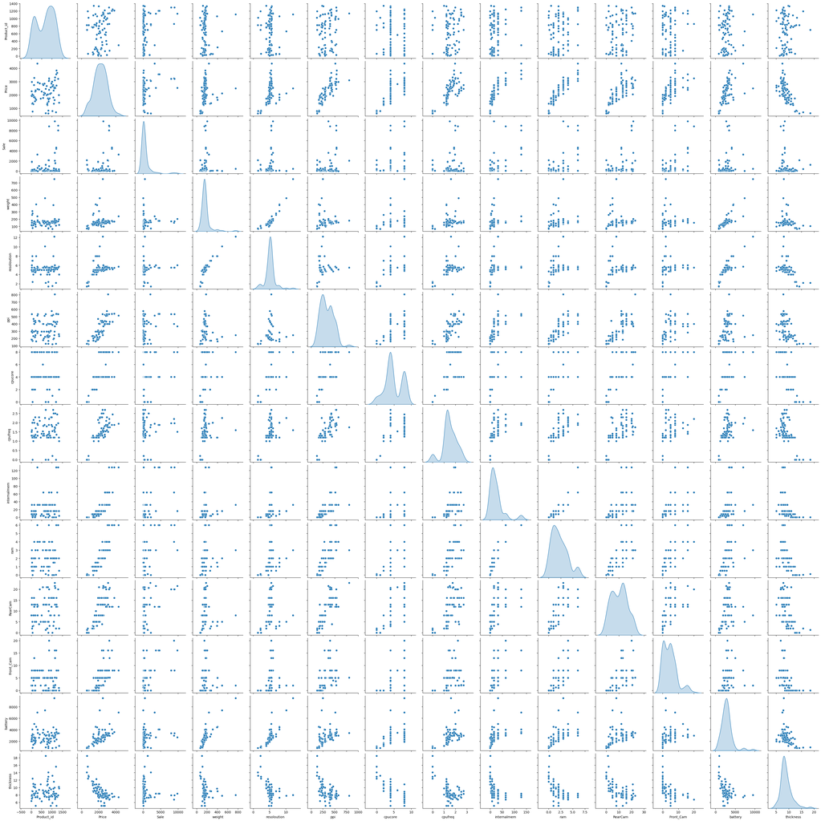

```python
import seaborn as sns
sns.pairplot(data,diag_kind='kde')
```

# Finding the corrtion b/w the dataset members

```python
data.corr()
```

|  | Product_id | Price | Sale | weight | resoloution | ppi | cpucore | cpufreq | internalmem | ram | RearCam | Front_Cam | battery | thickness |
| --- | --- | --- | --- | --- | --- | --- | --- | --- | --- | --- | --- | --- | --- | --- |
| Product_id | 1.000000 | 0.165136 | 0.218548 | 0.035869 | -0.017817 | 0.207271 | -0.008634 | 0.092428 | 0.261186 | 0.236194 | 0.172812 | 0.071020 | 0.031745 | 0.039807 |
| Price | 0.165136 | 1.000000 | 0.273263 | 0.144555 | 0.404010 | 0.817614 | 0.686811 | 0.727383 | 0.776738 | 0.896915 | 0.739538 | 0.675286 | 0.559946 | -0.716773 |
| Sale | 0.218548 | 0.273263 | 1.000000 | 0.016114 | 0.017154 | 0.235896 | 0.069517 | 0.099133 | 0.489308 | 0.373127 | 0.292164 | 0.437233 | 0.120338 | -0.047991 |
| weight | 0.035869 | 0.144555 | 0.016114 | 1.000000 | 0.890416 | -0.054683 | 0.216257 | 0.222730 | 0.098849 | 0.149283 | -0.029448 | -0.005971 | 0.833783 | -0.185262 |
| resoloution | -0.017817 | 0.404010 | 0.017154 | 0.890416 | 1.000000 | 0.181292 | 0.472226 | 0.505454 | 0.202660 | 0.327216 | 0.249892 | 0.202720 | 0.843462 | -0.533708 |
| ppi | 0.207271 | 0.817614 | 0.235896 | -0.054683 | 0.181292 | 1.000000 | 0.487990 | 0.713168 | 0.618560 | 0.748724 | 0.774008 | 0.491371 | 0.302517 | -0.496791 |
| cpucore | -0.008634 | 0.686811 | 0.069517 | 0.216257 | 0.472226 | 0.487990 | 1.000000 | 0.491519 | 0.276251 | 0.483128 | 0.611353 | 0.586698 | 0.459728 | -0.697935 |
| cpufreq | 0.092428 | 0.727383 | 0.099133 | 0.222730 | 0.505454 | 0.713168 | 0.491519 | 1.000000 | 0.441400 | 0.633547 | 0.625104 | 0.358319 | 0.473137 | -0.614458 |
| internalmem | 0.261186 | 0.776738 | 0.489308 | 0.098849 | 0.202660 | 0.618560 | 0.276251 | 0.441400 | 1.000000 | 0.875354 | 0.451917 | 0.555733 | 0.461506 | -0.367412 |
| ram | 0.236194 | 0.896915 | 0.373127 | 0.149283 | 0.327216 | 0.748724 | 0.483128 | 0.633547 | 0.875354 | 1.000000 | 0.648073 | 0.647470 | 0.541001 | -0.521074 |
| RearCam | 0.172812 | 0.739538 | 0.292164 | -0.029448 | 0.249892 | 0.774008 | 0.611353 | 0.625104 | 0.451917 | 0.648073 | 1.000000 | 0.596374 | 0.287821 | -0.550998 |
| Front_Cam | 0.071020 | 0.675286 | 0.437233 | -0.005971 | 0.202720 | 0.491371 | 0.586698 | 0.358319 | 0.555733 | 0.647470 | 0.596374 | 1.000000 | 0.295283 | -0.493542 |
| battery | 0.031745 | 0.559946 | 0.120338 | 0.833783 | 0.843462 | 0.302517 | 0.459728 | 0.473137 | 0.461506 | 0.541001 | 0.287821 | 0.295283 | 1.000000 | -0.412682 |
| thickness | 0.039807 | -0.716773 | -0.047991 | -0.185262 | -0.533708 | -0.496791 | -0.697935 | -0.614458 | -0.367412 | -0.521074 | -0.550998 | -0.493542 | -0.412682 | 1.000000 |

# Plootting the heatmap of all dataset members

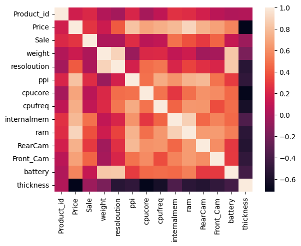

```python
import seaborn as sns
sns.heatmap(data.corr())
```

```python
# Finding the shape of dataset
```

```python
data.shape
```

```
(161, 14)
```

# Plotting the graph b/w independent variable and dependent variable ,here assuming that sale as y and weight and others are independent variable

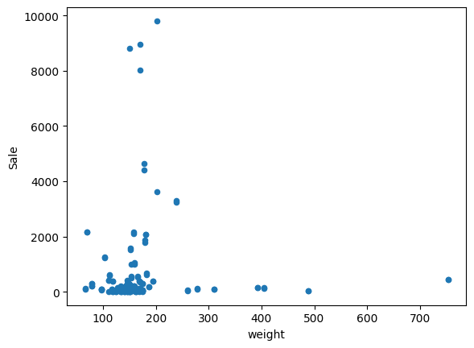

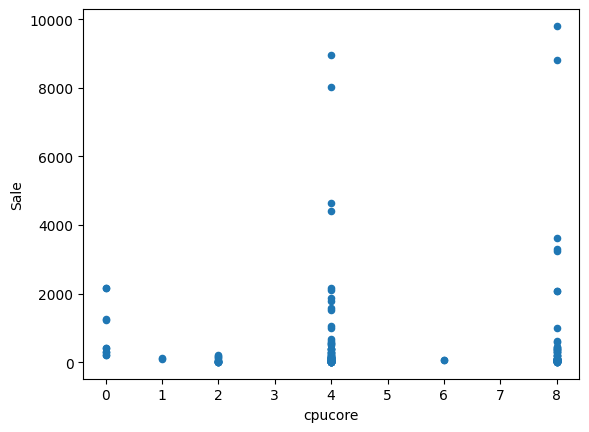

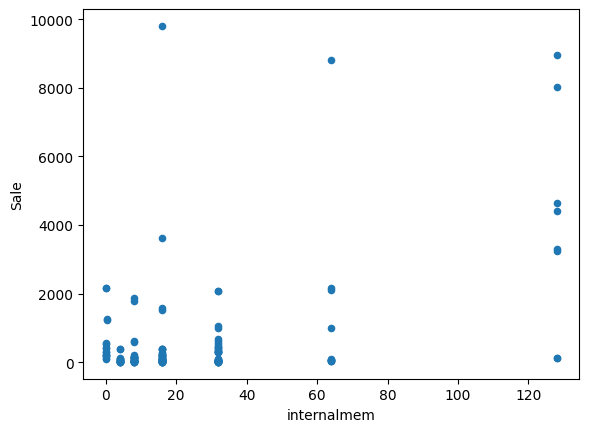

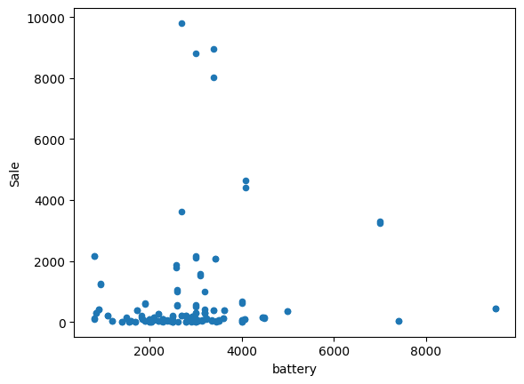

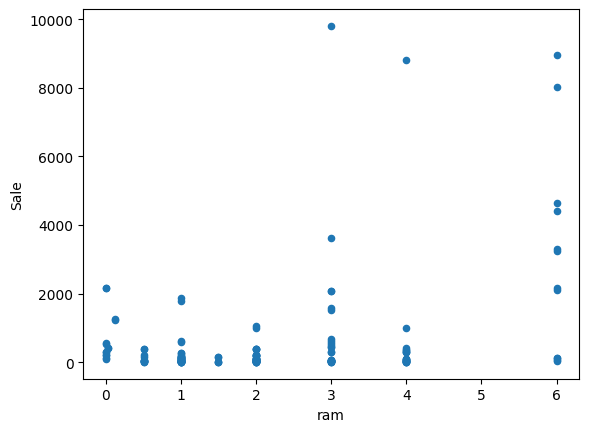

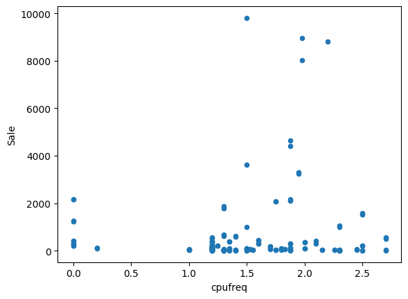

```python
data.plot(kind='scatter', x='weight', y='Sale')
data.plot(kind='scatter', x='cpucore', y='Sale')
data.plot(kind='scatter', x='internalmem', y='Sale')
data.plot(kind='scatter', x='battery', y='Sale')
data.plot(kind='scatter', x='ram', y='Sale')
data.plot(kind='scatter', x='cpufreq', y='Sale')
```

```python
feature_cols = ['battery']
X = data[feature_cols]
y = data.Sale


from sklearn.linear_model import LinearRegression
lm = LinearRegression()
lm.fit(X, y)


print(lm.intercept_)
print(lm.coef_)
```

```
234.50869381574506
[0.13615127]
```

# Manually calculate the sale of the new battery mah if we give

# Hypothesis Testing and p-values

```python
234.50+0.13*6700
```

```
1105.5
```

```python
X_new = pd.DataFrame({'battery': [6700]})
X_new.head()
```

|  | battery |
| --- | --- |
| 0 | 6700 |

```python
lm.predict(X_new)
```

```
array([1146.72223458])
```

```python
X_new = pd.DataFrame({'battery': [data.battery.min(), data.battery.max()]})
X_new.head()
```

|  | battery |
| --- | --- |
| 0 | 800 |
| 1 | 9500 |

```python
preds = lm.predict(X_new)
preds
```

```
array([ 343.42971361, 1527.94580385])
```

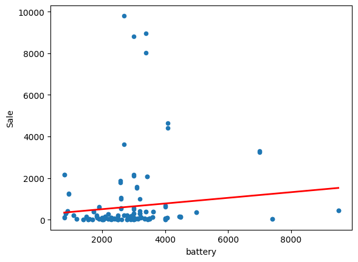

```python
data.plot(kind='scatter', x='battery', y='Sale')

# then, plot the least squares line
plt.plot(X_new, preds, c='red', linewidth=2)
```

```python
pip install statsmodels
```

[output not shown]

# Doing linear regression only in b/w battery and sales

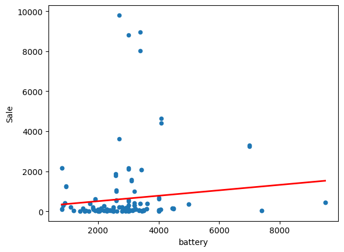

```python
data.plot(kind='scatter', x='battery', y='Sale')

# then, plot the least squares line
plt.plot(X_new, preds, c='red', linewidth=2)
```

```python
import statsmodels.formula.api as smf
lm = smf.ols(formula='Sale ~ battery', data=data).fit()
lm.conf_int()
```

|  | 0 | 1 |
| --- | --- | --- |
| Intercept | -319.981885 | 788.999273 |
| battery | -0.039770 | 0.312072 |

# calculating p values for the datset

```python
lm.pvalues
```

```
Intercept    0.404815
battery      0.128371
dtype: float64
```

# Finding rsquared for the model

```python
# print the R-squared value for the model
lm.rsquared
```

```
0.014481322315810008
```

# Creating the model for multiple linear regression

# Multiple Linear Regression

```python
feature_cols = ['battery', 'weight', 'ram','thickness','ppi','Price']
X = data[feature_cols]
y = data.Sale

lm = LinearRegression()
lm.fit(X, y)

# print intercept and coefficients
print(lm.intercept_)
print(lm.coef_)
```

```
-1775.6457896283391
[-4.33736793e-01  4.34508920e+00  5.58054483e+02  1.48063422e+02
 -1.02518317e+00  3.07514198e-01]
```

# Finding the rsquared value and p value for the given model

we are taking adj.R value because it gives better accuracy for prediting

```python
lm = smf.ols(formula='Sale ~ battery+weight+ram+thickness+ppi+Price', data=data).fit()
lm.conf_int()
lm.summary()
```

OLS Regression Results

| Dep. Variable: | Sale | R-squared: | 0.185 |
| --- | --- | --- | --- |
| Model: | OLS | Adj. R-squared: | 0.154 |
| Method: | Least Squares | F-statistic: | 5.841 |
| Date: | Thu, 18 Jan 2024 | Prob (F-statistic): | 1.65e-05 |
| Time: | 20:10:30 | Log-Likelihood: | -1393.8 |
| No. Observations: | 161 | AIC: | 2802. |
| Df Residuals: | 154 | BIC: | 2823. |
| Df Model: | 6 |  |  |
| Covariance Type: | nonrobust |  |  |

|  | coef | std err | t | P>\|t\| | [0.025 | 0.975] |
| --- | --- | --- | --- | --- | --- | --- |
| Intercept | -1775.6458 | 1415.307 | -1.255 | 0.212 | -4571.568 | 1020.277 |
| battery | -0.4337 | 0.263 | -1.652 | 0.101 | -0.952 | 0.085 |
| weight | 4.3451 | 3.201 | 1.357 | 0.177 | -1.979 | 10.670 |
| ram | 558.0545 | 173.459 | 3.217 | 0.002 | 215.388 | 900.721 |
| thickness | 148.0634 | 84.205 | 1.758 | 0.081 | -18.282 | 314.409 |
| ppi | -1.0252 | 1.576 | -0.650 | 0.516 | -4.139 | 2.088 |
| Price | 0.3075 | 0.575 | 0.534 | 0.594 | -0.829 | 1.444 |

| Omnibus: | 146.081 | Durbin-Watson: | 0.413 |
| --- | --- | --- | --- |
| Prob(Omnibus): | 0.000 | Jarque-Bera (JB): | 2017.437 |
| Skew: | 3.371 | Prob(JB): | 0.00 |
| Kurtosis: | 18.978 | Cond. No. | 4.92e+04 |

Notes:  
[1] Standard Errors assume that the covariance matrix of the errors is correctly specified.  
[2] The condition number is large, 4.92e+04. This might indicate that there are  
strong multicollinearity or other numerical problems.

```python
from sklearn.linear_model import LinearRegression
```

```python
mylm = LinearRegression()
```

```python
mylm.fit(X,y)
```

```
LinearRegression()
```

```python
print(mylm.intercept_)
```

[output not shown]

```python
predictions = mylm.predict(X)
```

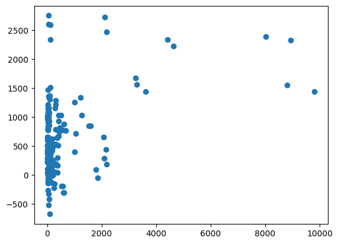

```python
plt.scatter(y,predictions)
```

# Finding the Mae And MSE ,RMSE value of the 1st Model

```python
from sklearn import metrics
print('MAE:', metrics.mean_absolute_error(y, predictions))
print('MSE:', metrics.mean_squared_error(y, predictions))
print('RMSE:', np.sqrt(metrics.mean_squared_error(y, predictions)))
```

[output not shown]

# Conclusion

Here we can say Ram is significant value later thickness and rest all the insignificant value so we can neglect it so we say that sale dependent mostly on ram and thickness

```python
from sklearn import metrics
```

```python
lm = smf.ols(formula='Sale ~ ram + thickness', data=data).fit()
lm.rsquared
```

```
0.16865917165969657
```

```python
lm = smf.ols(formula='Sale ~ ram + thickness + battery+weight', data=data).fit()
lm.rsquared
```

```
0.18288036467961633
```

```python
lm = smf.ols(formula='Sale ~ ram + thickness + battery+weight+ ppi', data=data).fit()
lm.rsquared
```

```
0.1838793223356857
```

# In taking the second the model we drop the price the and then we say is there improvement in adjusted r squared value

```python
lm = smf.ols(formula='Sale ~ battery+weight+ram+thickness+ppi', data=data).fit()
lm.conf_int()
lm.summary()
```

OLS Regression Results

| Dep. Variable: | Sale | R-squared: | 0.184 |
| --- | --- | --- | --- |
| Model: | OLS | Adj. R-squared: | 0.158 |
| Method: | Least Squares | F-statistic: | 6.985 |
| Date: | Thu, 18 Jan 2024 | Prob (F-statistic): | 6.53e-06 |
| Time: | 20:35:20 | Log-Likelihood: | -1393.9 |
| No. Observations: | 161 | AIC: | 2800. |
| Df Residuals: | 155 | BIC: | 2818. |
| Df Model: | 5 |  |  |
| Covariance Type: | nonrobust |  |  |

|  | coef | std err | t | P>\|t\| | [0.025 | 0.975] |
| --- | --- | --- | --- | --- | --- | --- |
| Intercept | -1173.8097 | 855.165 | -1.373 | 0.172 | -2863.091 | 515.471 |
| battery | -0.3704 | 0.234 | -1.585 | 0.115 | -0.832 | 0.091 |
| weight | 3.6864 | 2.948 | 1.251 | 0.213 | -2.137 | 9.509 |
| ram | 617.2612 | 133.156 | 4.636 | 0.000 | 354.227 | 880.295 |
| thickness | 118.1313 | 62.728 | 1.883 | 0.062 | -5.780 | 242.043 |
| ppi | -0.5829 | 1.338 | -0.436 | 0.664 | -3.226 | 2.061 |

| Omnibus: | 147.224 | Durbin-Watson: | 0.412 |
| --- | --- | --- | --- |
| Prob(Omnibus): | 0.000 | Jarque-Bera (JB): | 2062.604 |
| Skew: | 3.404 | Prob(JB): | 0.00 |
| Kurtosis: | 19.159 | Cond. No. | 2.43e+04 |

Notes:  
[1] Standard Errors assume that the covariance matrix of the errors is correctly specified.  
[2] The condition number is large, 2.43e+04. This might indicate that there are  
strong multicollinearity or other numerical problems.

# Finding Mae ,Mse,Rmse for the second model

```
-1173.8096689676877
MAE: 752.7352354387308
MSE: 1940058.8284918251
RMSE: 1392.85994575615
```

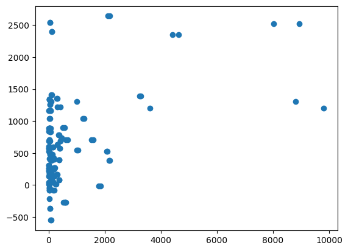

```python
feature_cols = ['battery', 'weight', 'ram','thickness','ppi']
X = data[feature_cols]
y = data.Sale
from sklearn.linear_model import LinearRegression
mylm = LinearRegression()
mylm.fit(X,y)
print(mylm.intercept_)
predictions = mylm.predict(X)
plt.scatter(y,predictions)
from sklearn import metrics
print('MAE:', metrics.mean_absolute_error(y, predictions))
print('MSE:', metrics.mean_squared_error(y, predictions))
print('RMSE:', np.sqrt(metrics.mean_squared_error(y, predictions)))
```

# We can clearly see that after dropping the column of price adjusted r square value increses

if the r squared value is increasing because we including more no of x column values so we only see through the adjusted r squared values

# Here we say that ram and thickness P value decreases and the model improves if we drops the value of price

# Now in the 3rd model we drop the ppi value and see how things changes

```python
lm = smf.ols(formula='Sale ~ battery+weight+ram+thickness', data=data).fit()
lm.conf_int()
lm.summary()
```

OLS Regression Results

| Dep. Variable: | Sale | R-squared: | 0.183 |
| --- | --- | --- | --- |
| Model: | OLS | Adj. R-squared: | 0.162 |
| Method: | Least Squares | F-statistic: | 8.729 |
| Date: | Thu, 18 Jan 2024 | Prob (F-statistic): | 2.20e-06 |
| Time: | 20:37:05 | Log-Likelihood: | -1394.0 |
| No. Observations: | 161 | AIC: | 2798. |
| Df Residuals: | 156 | BIC: | 2813. |
| Df Model: | 4 |  |  |
| Covariance Type: | nonrobust |  |  |

|  | coef | std err | t | P>\|t\| | [0.025 | 0.975] |
| --- | --- | --- | --- | --- | --- | --- |
| Intercept | -1373.7771 | 719.611 | -1.909 | 0.058 | -2795.216 | 47.661 |
| battery | -0.3784 | 0.232 | -1.628 | 0.106 | -0.837 | 0.081 |
| weight | 3.9365 | 2.884 | 1.365 | 0.174 | -1.760 | 9.633 |
| ram | 586.4304 | 112.491 | 5.213 | 0.000 | 364.227 | 808.633 |
| thickness | 124.0462 | 61.081 | 2.031 | 0.044 | 3.394 | 244.699 |

| Omnibus: | 147.764 | Durbin-Watson: | 0.409 |
| --- | --- | --- | --- |
| Prob(Omnibus): | 0.000 | Jarque-Bera (JB): | 2082.172 |
| Skew: | 3.420 | Prob(JB): | 0.00 |
| Kurtosis: | 19.236 | Cond. No. | 2.05e+04 |

Notes:  
[1] Standard Errors assume that the covariance matrix of the errors is correctly specified.  
[2] The condition number is large, 2.05e+04. This might indicate that there are  
strong multicollinearity or other numerical problems.